# Case 6126-E08 Kmeans - R Notebook for Python

https://teachdatascience.com/reticulate

https://rstudio-pubs-static.s3.amazonaws.com/188357_03392d56ec074b5e947b17ca8976d8be.html

https://uc-r.github.io/kmeans_clustering

https://www.r-bloggers.com/2014/10/working-with-nifti-images-in-r

https://www.r-bloggers.com/2014/06/fslr-an-r-package-interfacing-with-fsl-for-neuroimaging-analysis

```r
library(reticulate)
wd <- '/Users/arvid/GitHub/BMED320-imaging-mass-cytometry-ml/notebooks/imc-case-damond-2019'
setwd(wd)
print(getwd())
```

```
[1] "/Users/arvid/GitHub/BMED320-imaging-mass-cytometry-ml/notebooks/imc-case-damond-2019"
```

```r
os <- import("os")
```

[output not shown]

```r
os$listdir()
```

```
 [1] ".Rhistory"
 [2] "read-analyze-case-6126-E08-ajia.ipynb"
 [3] ".DS_Store"
 [4] "testing-R-notebook_with-Python-reticulate.Rmd"
 [5] "histoCAT_CustomNeighborhoodAnalysisFunctions"
 [6] "test_data"
 [7] "case-6126-E08-kmeans.nb.html"
 [8] "CoordinatesTransformation_IF-IMC.ipynb"
 [9] "mlruns"
[10] "logs.log"
[11] "README.md"
[12] "case-6126-E08-kmeans.Rmd"
[13] ".ipynb_checkpoints"
[14] "read-analyze-case-6126-E08.ipynb"
[15] "data"
[16] "assets"
[17] "testing-R-notebook_with-Python-reticulate.nb.html"
```

```r
library(reticulate)
# cat $HOME/.Renviron
# RETICULATE_PYTHON="/Users/arvid/opt/anaconda3/envs/imc/bin/python"
print(Sys.which("python"))
```

```
                                          python
"/Users/arvid/opt/anaconda3/envs/imc/bin/python"
```

```r
use_python("/Users/arvid/opt/anaconda3/envs/imc/bin/python", required=TRUE)
print(Sys.which("python"))
```

```
                                          python
"/Users/arvid/opt/anaconda3/envs/imc/bin/python"
```

```r
use_condaenv(condaenv ="imc", conda = "auto", required = TRUE)
```

```r
library("reticulate")
py_discover_config()
```

```
python:         /Users/arvid/opt/anaconda3/envs/imc/bin/python
libpython:      /Users/arvid/opt/anaconda3/envs/imc/lib/libpython3.7m.dylib
pythonhome:     /Users/arvid/opt/anaconda3/envs/imc:/Users/arvid/opt/anaconda3/envs/imc
version:        3.7.9 (default, Aug 31 2020, 07:22:35)  [Clang 10.0.0 ]
numpy:          /Users/arvid/opt/anaconda3/envs/imc/lib/python3.7/site-packages/numpy
numpy_version:  1.19.1

NOTE: Python version was forced by RETICULATE_PYTHON
```

```r
library(oro.nifti)

fn <- 'data/imc_37_chns.nii.gz'
img <- readNIfTI(fn)
class(img)
```

```
[1] "nifti"
attr(,"package")
[1] "oro.nifti"
```

```r
print(img)
```

```
NIfTI-1 format
  Type            : nifti
  Data Type       : 64 (FLOAT64)
  Bits per Pixel  : 64
  Slice Code      : 0 (Unknown)
  Intent Code     : 0 (None)
  Qform Code      : 0 (Unknown)
  Sform Code      : 2 (Aligned_Anat)
  Dimension       : 567 x 530 x 1 x 37
  Pixel Dimension : 1 x 1 x 1 x 1
  Voxel Units     : Unknown
  Time Units      : Unknown
```

```r
slotNames(img)
```

```
 [1] ".Data"          "sizeof_hdr"     "data_type"      "db_name"
 [5] "extents"        "session_error"  "regular"        "dim_info"
 [9] "dim_"           "intent_p1"      "intent_p2"      "intent_p3"
[13] "intent_code"    "datatype"       "bitpix"         "slice_start"
[17] "pixdim"         "vox_offset"     "scl_slope"      "scl_inter"
[21] "slice_end"      "slice_code"     "xyzt_units"     "cal_max"
[25] "cal_min"        "slice_duration" "toffset"        "glmax"
[29] "glmin"          "descrip"        "aux_file"       "qform_code"
[33] "sform_code"     "quatern_b"      "quatern_c"      "quatern_d"
[37] "qoffset_x"      "qoffset_y"      "qoffset_z"      "srow_x"
[41] "srow_y"         "srow_z"         "intent_name"    "magic"
[45] "extender"       "reoriented"
```

```r
print(img@bitpix)
```

```
[1] 64
```

```r
print(img@datatype)
```

```
[1] 64
```

```r
print(max(img))
```

```
[1] 1
```

```r
print(dim(img))
```

```
[1] 567 530   1  37
```

```r
print(img@dim_)
```

```
[1]   4 567 530   1  37   1   1   1
```

```r
print(pixdim(img))
```

```
[1] 1 1 1 1 1 1 1 1
```

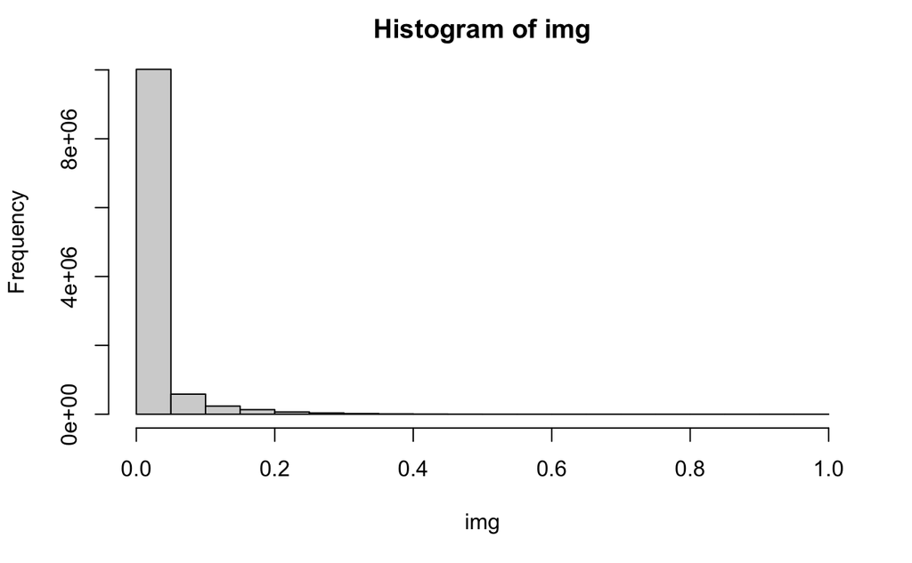

```r
hist(img)
```

```r
library(imager)
img_imc = squeeze(img)
dim(img_imc)
```

```
[1] 567 530  37
```

Advanced Techniques With Raster Data: Part 1 – Unsupervised Classification 28 February 2018 by João Gonçalves

https://www.r-exercises.com/2018/02/28/advanced-techniques-with-raster-data-part-1-unsupervised-classification/

Read and plot the IMC data in the RGB display (bands 4,3,2) to see if everything is fine:

```
layer was changed to 1layer was changed to 1layer was changed to 1
```

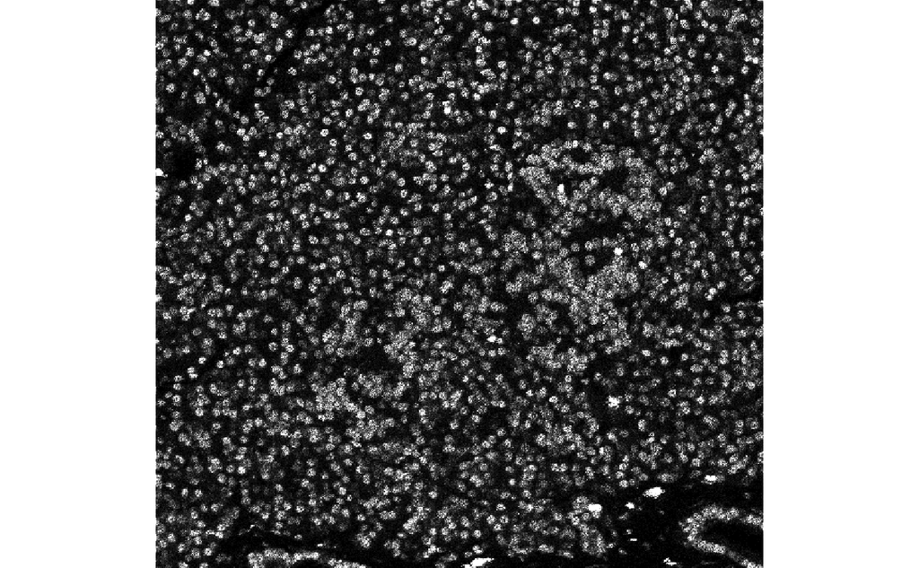

```r
library(raster)
library(rgdal)

fnt <- 'data/E08_a0_full.tiff'
rst <- brick(fnt)

plotRGB(rst, r=4, g=3, b=2, scale=10000, stretch="lin", main="RGB composite (b4,b3,b2) of E08_a0_full.tiff")
```

```r
library(cluster)

# Extract all values from the raster into a data frame
rstDF <- values(rst)

# Check NA's in the data
idx <- complete.cases(rstDF)
```

```r
library(cluster)
# Initiate the raster datasets that will hold all clustering solutions
# from 2 groups/clusters up to 12
rstKM <- raster(rst[[1]])
rstCLARA <- raster(rst[[1]])
```

```r
library(cluster)

for(nClust in 2:12){

  cat("-> Clustering data for nClust =",nClust,"......")

  # Perform K-means clustering
  km <- kmeans(rstDF[idx,], centers = nClust, iter.max = 50)

  # Perform CLARA's clustering (using manhattan distance)
  cla <- clara(rstDF[idx, ], k = nClust, metric = "manhattan")

  # Create a temporary integer vector for holding cluster numbers
  kmClust <- vector(mode = "integer", length = ncell(rst))
  claClust <- vector(mode = "integer", length = ncell(rst))

  # Generate the temporary clustering vector for K-means (keeps track of NA's)
  kmClust[!idx] <- NA
  kmClust[idx] <- km$cluster

  # Generate the temporary clustering vector for CLARA (keeps track of NA's too ;-)
  claClust[!idx] <- NA
  claClust[idx] <- cla$clustering

  # Create a temporary raster for holding the new clustering solution
  # K-means
  tmpRstKM <- raster(rst[[1]])
  # CLARA
  tmpRstCLARA <- raster(rst[[1]])

  # Set raster values with the cluster vector
  # K-means
  values(tmpRstKM) <- kmClust
  # CLARA
  values(tmpRstCLARA) <- claClust

  # Stack the temporary rasters onto the final ones
  if(nClust==2){
    rstKM    <- tmpRstKM
    rstCLARA <- tmpRstCLARA
  }else{
    rstKM    <- stack(rstKM, tmpRstKM)
    rstCLARA <- stack(rstCLARA, tmpRstCLARA)
  }

  cat(" done!\n\n")
}
```

```
-> Clustering data for nClust = 2 ...... done!

-> Clustering data for nClust = 3 ...... done!

-> Clustering data for nClust = 4 ......
```

```
Quick-TRANSfer stage steps exceeded maximum (= 15025500)
```

```
 done!

-> Clustering data for nClust = 5 ...... done!

-> Clustering data for nClust = 6 ...... done!

-> Clustering data for nClust = 7 ...... done!

-> Clustering data for nClust = 8 ...... done!

-> Clustering data for nClust = 9 ......
```

```
Quick-TRANSfer stage steps exceeded maximum (= 15025500)
```

```
 done!

-> Clustering data for nClust = 10 ......
```

```
Quick-TRANSfer stage steps exceeded maximum (= 15025500)
```

```
 done!

-> Clustering data for nClust = 11 ......
```

```
Quick-TRANSfer stage steps exceeded maximum (= 15025500)
```

```
 done!

-> Clustering data for nClust = 12 ...... done!
```

```r
library(cluster)

# Write the clustering solutions for each algorithm
writeRaster(rstKM,"./data/E08_a0_full_KMeans_nc2_12.tiff", overwrite=TRUE)
```

```
NOT UPDATED FOR PROJ >= 6
```

```r
writeRaster(rstCLARA,"./data/E08_a0_full_CLARA_nc2_12.tiff", overwrite=TRUE)
```

```
NOT UPDATED FOR PROJ >= 6
```

Evaluating Unsupervised Classification/Clustering Performance

More specifically, the silhouette refers to a method of interpreting and validating the consistency within clusters of data (hence its called an internal criteria in clusterCrit package.) In a nutshell, this method provides a graphical representation that depicts how well each clustered object lies within its cluster. Also, the silhouette value is a measure of how similar an object is to its own cluster (assessing intra-cluster cohesion) compared to other clusters (denoting between-clusters’ separation).

The silhouette index ranges from −1 to +1, where a high value indicates that the object is well matched to its own cluster and poorly matched to neighboring clusters. If most objects have a high value, then the clustering configuration is considered appropriate. If many points have a low or negative value, then the clustering configuration may have too many or too few clusters.

In R, the clusterCrit package provides an implementation of this internal clustering criteria in the intCriteria(among many others, such as the Dunn, Ball-Hall, Davies-Bouldin, GDI, Tau indices.) Check out library(help=“clusterCrit”) and vignette(“clusterCrit”) for more info on this package.

Now that we have defined the conceptual underpinnings of the silhouette index, we can implement it in R code. One important detail before we proceed: since calculating the silhouette index is a rather slow process for large numbers’ of observations (>5000), we will use a stratified random sampling approach.

This means that we will take a sub-set of cells from each cluster and calculate the index based on those. We are assuming that the sample is somewhat robust and representative of the whole cells. Ideally, this process should be repeated several times and then an average value could be calculated (using a bootstrap approach would also be nice here.) However, for the sake of simplicity (and also because estimation generally yields relatively low errors… you have to trust me here… ) we will use a single sample of cells in this example.

```r
library(clusterCrit)

# Start a data frame that will store all silhouette values
# for k-means and CLARA
clustPerfSI <- data.frame(nClust = 2:12, SI_KM = NA, SI_CLARA = NA)


for(i in 1:nlayers(rstKM)){ # Iterate through each layer

  cat("-> Evaluating clustering performance for nClust =",(2:12)[i],"......")

  # Extract random cell samples stratified by cluster
  cellIdx_RstKM <- sampleStratified(rstKM[[i]], size = 2000)
  cellIdx_rstCLARA <- sampleStratified(rstCLARA[[i]], size = 2000)

  # Get cell values from the Stratified Random Sample from the raster
  # data frame object (rstDF)
  rstDFStRS_KM <- rstDF[cellIdx_RstKM[,1], ]
  rstDFStRS_CLARA <- rstDF[cellIdx_rstCLARA[,1], ]

  # Make sure all columns are numeric (intCriteria function is picky on this)
  rstDFStRS_KM[] <- sapply(rstDFStRS_KM, as.numeric)
  rstDFStRS_CLARA[] <- sapply(rstDFStRS_CLARA, as.numeric)

  # Compute the sample-based Silhouette index for:
  #
  # K-means
  clCritKM <- intCriteria(traj = rstDFStRS_KM,
                          part = as.integer(cellIdx_RstKM[,2]),
                          crit = "Silhouette")
  # and CLARA
  clCritCLARA <- intCriteria(traj = rstDFStRS_CLARA,
                             part = as.integer(cellIdx_rstCLARA[,2]),
                             crit = "Silhouette")

  # Write the silhouette index value to clustPerfSI data frame holding
  # all results
  clustPerfSI[i, "SI_KM"]    <- clCritKM[[1]][1]
  clustPerfSI[i, "SI_CLARA"] <- clCritCLARA[[1]][1]

  cat(" done!\n\n")

}
```

```
-> Evaluating clustering performance for nClust = 2 ......
```

```
Error in intCriteria(traj = rstDFStRS_KM, part = as.integer(cellIdx_RstKM[,  :
  argument 'traj' must be a matrix
```

```python
import pandas as pd
fn = 'test_data/flights.csv'
flights = pd.read_csv(fn, sep = ';')
```

library(cluster)

```python
reticulate::repl_python()
```

```
Python 3.7.9 (/Users/arvid/opt/anaconda3/envs/imc/bin/python)
Reticulate 1.18 REPL -- A Python interpreter in R.
```

```python
import pandas as pd
fn = 'test_data/flights.csv'
flights = pd.read_csv(fn, sep = ';')
flights = flights[flights['dest'] == 'ORD']
flighhs = flights[['carrier', 'dep_delay', 'arr_delay']]
flights = flights.dropna()
flights['month'] = pd.DatetimeIndex(flights['date']).month
flights.columns.T
```

```
Index(['date', 'hour', 'minute', 'dep', 'arr', 'dep_delay', 'arr_delay',
       'carrier', 'flight', 'dest', 'plane', 'cancelled', 'time', 'dist',
       'month'],
      dtype='object')
```

```python
flights.shape
```

```
(5634, 15)
```

```python
flights.head(5)
```

```
                    date  hour  minute     dep  ...  cancelled   time  dist month
369  2011-01-31 12:00:00  14.0    22.0  1422.0  ...          0  114.0   925     1
416  2011-01-31 12:00:00  19.0    25.0  1925.0  ...          0  117.0   925     1
417  2011-01-31 12:00:00   5.0    54.0   554.0  ...          0  117.0   925     1
432  2011-01-31 12:00:00  11.0    46.0  1146.0  ...          0  116.0   925     1
461  2011-01-31 12:00:00  14.0    23.0  1423.0  ...          0  114.0   925     1

[5 rows x 15 columns]
```

```python
flights.describe()
```

```
              hour       minute          dep  ...         time    dist        month
count  5634.000000  5634.000000  5634.000000  ...  5634.000000  5634.0  5634.000000
mean     13.037451    31.265708  1335.010827  ...   123.212105   925.0     6.585729
std       4.669688    15.933396   464.431305  ...     9.585956     0.0     3.402234
min       0.000000     0.000000    17.000000  ...   100.000000   925.0     1.000000
25%       9.000000    20.000000   930.750000  ...   117.000000   925.0     4.000000
50%      14.000000    32.000000  1408.500000  ...   122.000000   925.0     7.000000
75%      17.000000    44.000000  1728.000000  ...   128.000000   925.0    10.000000
max      23.000000    59.000000  2333.000000  ...   215.000000   925.0    12.000000

[8 rows x 11 columns]
```

```python
flights.groupby('carrier').mean()
```

```
              hour     minute          dep  ...        time   dist     month
carrier                                     ...
CO       13.499272  30.542965  1380.470143  ...  123.476551  925.0  6.515293
MQ       12.626189  32.381127  1295.000000  ...  122.160936  925.0  6.550841
OO        6.261146  30.598726   656.713376  ...  125.385350  925.0  8.082803
UA       15.152216  33.491329  1548.712909  ...  122.913295  925.0  6.246628
XE       20.000000  42.000000  2042.000000  ...  125.000000  925.0  2.000000

[5 rows x 11 columns]
```

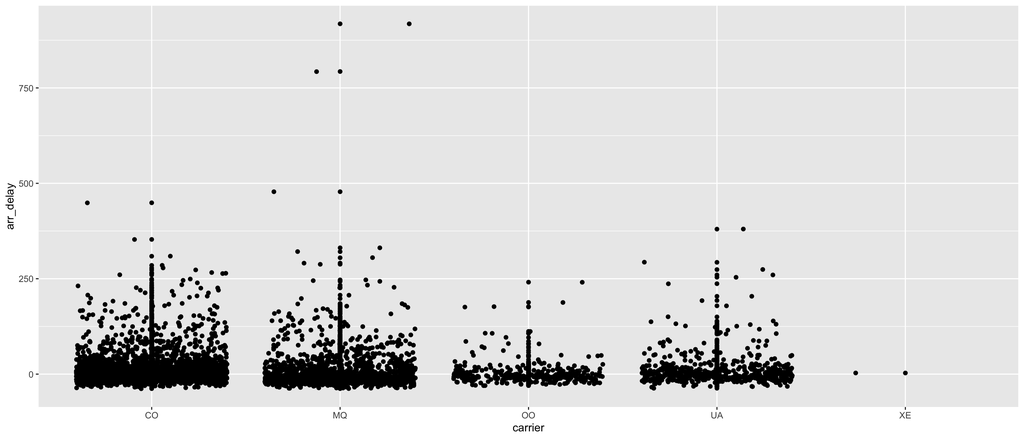

```r
quit
library(ggplot2)
ggplot(py$flights, aes(carrier, arr_delay)) + geom_point() + geom_jitter()
```

```r
library(dplyr)
py$flights %>%
  dplyr::select(carrier, dep_delay, arr_delay) %>%
  tidyr::drop_na() %>%
  group_by(carrier) %>%
  summarize(mean_dep_delay = mean(dep_delay), mean_arr_delay = mean(arr_delay))
```

| carrier | mean_dep_delay | mean_arr_delay |
| --- | --- | --- |
| CO | 14.565395 | 10.757064 |
| MQ | 15.636430 | 9.521580 |
| OO | 5.659236 | 2.821656 |
| UA | 14.321773 | 12.254335 |
| XE | 12.000000 | 3.000000 |

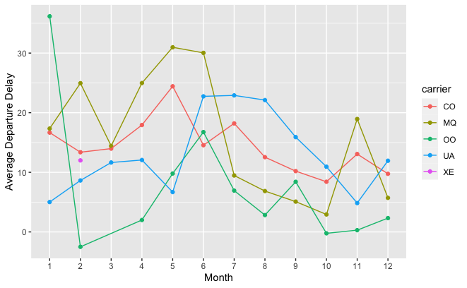

```r
library(ggplot2)
py$flights %>%
  tidyr::drop_na() %>%
  group_by(carrier, month) %>%
  summarize(mean_dep_delay = mean(dep_delay)) %>%
  ggplot(aes(x=as.factor(month), y = mean_dep_delay, group = carrier, color=carrier))  +
  geom_point() + geom_line() + xlab("Month") + ylab("Average Departure Delay")
```